# Lab 6 - JPEG Compressionend

## Goal: Introduction of principles of the JPEG baseline coding system.

Import the necessary libraries:

```python
%matplotlib inline
import numpy as np
import matplotlib.pyplot as plt
from skimage import transform,io,util,img_as_ubyte,color
from skimage import restoration
import sys
import math
from PIL import Image
from scipy import fftpack
```

help functions:

```python
def load_quantization_table(quality,block_size):
  #  if block_size==8:
    q = np.array([[16, 11, 10, 16, 24, 40, 51, 61],
            [12, 12, 14, 19, 26, 58, 60, 55],
            [14, 13, 16, 24, 40, 57, 69, 56],
            [14, 17, 22, 29, 51, 87, 80, 62],
            [18, 22, 37, 56, 68, 109, 103, 77],
            [24, 35, 55, 64, 81, 104, 113, 92],
            [49, 64, 78, 87, 103, 121, 120, 101],
            [72, 92, 95, 98, 112, 100, 103, 99]])* quality   # JPEG normalizing array and zig-zag reordering
    if (block_size==16):
        q=transform.resize(q,(16,16),preserve_range=True)
    if (block_size==4):
        q=transform.resize(q,(4,4),preserve_range=True)
    return q

def quantize(block, quality,block_size):
    q = load_quantization_table(quality,block_size)
    return np.array((block / q).round().astype(np.int32))

def dequantize(block, quality,block_size):
    q = load_quantization_table(quality,block_size)
    return block * q

def block_to_zigzag(block, order):
    flat_bloack = block.flatten()
    reorder_flat_block = np.array([flat_bloack[point] for point in order])
    return reorder_flat_block

def zigzag_to_block(zigzag, order):
     # assuming that the width and the height of the block are equal
    rows = cols = int(math.sqrt(len(zigzag)))
    if rows * cols != len(zigzag):
        raise ValueError("length of zigzag should be a perfect square")

    block = np.empty((rows*cols), np.int32)

    for i, point in enumerate(order):
        block[point] = zigzag[i]
    return block.reshape((rows,cols))

def dct_2d(image):
    return fftpack.dct(fftpack.dct(image.T, norm='ortho').T, norm='ortho')

def idct_2d(image):
    block = fftpack.idct(fftpack.idct(image.T, norm='ortho').T, norm='ortho')
    block[block>127] =127
    return block

zigzag_order_8x8 = [ 0 , 8 , 1 , 2 ,9 ,16, 24, 17, 10 , 3 , 4, 11 ,18, 25, 32,
         40 ,33, 26, 19, 12 , 5 , 6 ,13 ,20 ,27, 34, 41, 48, 56 ,49,
         42, 35, 28, 21 ,14,  7,15 ,22 ,29 ,36, 43, 50,57, 58, 51 ,
         44, 37, 30, 23, 31, 38, 45, 52, 59, 60, 53, 46, 39, 47, 54 ,
         61, 62, 55 ,63]
```

Load and show the image of your choice. Make sure your image is:

1. Black and white
2. Square shaped (the shape should be of the form (x,x))

```
Image shape:(512, 512), Image data type:uint32
```

[figure not shown]

```python
img = io.imread('bmp.bmp')
img=color.rgb2gray(img)
img = np.uint32(img_as_ubyte(img))
print("Image shape:{}, Image data type:{}".format(img.shape,img.dtype))
plt.imshow(img, cmap='gray')
plt.show()
```

For each image perform the following tasks:

1. Compress the image using the JPEG compression algorithm (use the supplied function *im2jpeg*). Restore the image from its compressed form using the supplied program *jpeg2im*.
   - Explain why blocking effects can be seen in the restored image.
   - Show the blocking effects by zoom in for intresting parrts of the image (use pycharm or crop the image and plot it separatly).

```python
# im2jpeg Compresses an image using a JPEG approximation.
# im2jpeg(img,block_size, quality) compresses image based on 8 x 8 DCT transforms and coefficient quantization.
# Input quality determines the amount of information that is lost and compression achieved.

def im2jpeg(img, block_size=8, quality = 1):
    if not isinstance(img, np.ndarray) or img.dtype != np.uint32:
        print("The input must be a UINT32 image.")
        return
    rows, cols = img.shape[0], img.shape[1]
    # block size: (block_size x block_size)
    if rows % block_size == cols % block_size == 0:
        blocks_count = rows // block_size * cols // block_size
    else:
        raise ValueError(("the width and height of the image "
                          "should both be mutiples of {}".format(block_size)))

    # End-Of-Block (EOB) symbol
    eob=256
    jpeg_list = list()
    # find the zigzag order
    if block_size == 8:
        order  = zigzag_order_8x8
    if block_size==16:
        order=zigzag_order_16x16
    if block_size==4:
        order=zigzag_order_4x4

    for i in range(0, rows, block_size):
        for j in range(0, cols, block_size):

                # split block_size x block_size block and center the data range on zero
                # [0, 255] --> [-128, 127]
                block = (img[i:i+block_size, j:j+block_size] - 128).astype(np.int32)
                # dct to the block
                dct_matrix = dct_2d(block)
                # quantize with quality factor
                quant_matrix = quantize(dct_matrix,quality,block_size)
                # reorder
                zz = block_to_zigzag(quant_matrix, order)
                # find the last non zero element
                last_non_zero = np.flatnonzero(zz)
                if last_non_zero.size == 0: # if all the block is zeros
                    last_non_zero = 0
                else:
                    last_non_zero = last_non_zero[-1]
                zz_no_zeros = np.zeros(last_non_zero+2,dtype=np.int32)
                zz_no_zeros[:last_non_zero+1] = zz[:last_non_zero+1]
                # add eob in the end of the block
                zz_no_zeros[last_non_zero+1] = eob
                # append the dct block to the list
                jpeg_list.append(zz_no_zeros)

    #convert the list to array
    jpeg_array = np.concatenate(jpeg_list,axis=None)
    return jpeg_array

# jpeg2im Decodes an IM2JPEG compressed image.
# jpeg2im(jpeg_img) decodes compressed image jpeg_img, generating reconstructed approximation X.
# jpeg_img is generated by im2jpeg.
def jpeg2im(jpeg_img, block_size=8, quality = 1):
    eob = 256
    # find the zigzag order
    if block_size == 8:
        order  = zigzag_order_8x8
    if block_size==16:
        order=zigzag_order_16x16
    if block_size==4:
        order=zigzag_order_4x4

    # find the End-Of-Block (EOB) symbols
    ends_of_blocks = np.where(jpeg_img == eob)[0]
    num_of_block = ends_of_blocks.shape[0]
    # assuming that the image height and width are equal
    image_side = int(math.sqrt(num_of_block)) * block_size
    blocks_per_line = image_side // block_size
    # create new empty image:
    npmat = np.empty((image_side, image_side), dtype=np.int32)
    start = 0
    for block_index, end in enumerate(ends_of_blocks):
        zigzag = np.zeros(block_size*block_size)
        zigzag[:end-start] = jpeg_img[start:end]
        quant_matrix = zigzag_to_block(zigzag, order)
        dct_matrix = dequantize(quant_matrix,quality,block_size)
        block = idct_2d(dct_matrix)
        # find the place in the image to put the block
        i = (block_index // blocks_per_line * block_size)
        j = (block_index % blocks_per_line * block_size)
        npmat[i:i+block_size, j:j+block_size] = block + 128
        start = end + 1

    return npmat
```

[figure not shown]

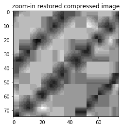

```python
jpeg_img=im2jpeg(img)
res_img=jpeg2im(jpeg_img)
plt.title("restored compressed image")
plt.imshow(res_img, cmap='gray')
plt.show()

res_img_zoom=res_img[100:175,100:175]
plt.title("zoom-in restored compressed image")
plt.imshow(res_img_zoom, cmap='gray')
plt.show()
```

we can see the blocking effect when zooming in. The JPEG algorithm divides the image to 8x8 blocks and preform the algorithm on each block separately, so the block effects we see are the boundaries between the blocks.

Attached zoom in of the image.

1. Plot the graph of compression ratio (Y axis) versus a “quality” parameter of *im2jpeg* (X axis). Use the supplied function *imratio*.

**Remark:** the “quality” parameter defines the quality of compression and not the quality of restoration. It is more (or equal) than 1. The “quality” equal to 1 corresponds to the best quality of restoration and the worst quality of compression.

```python
def imratio(original_img1,compressed_img2):
    return float(compressed_img2.nbytes)/original_img1.nbytes
```

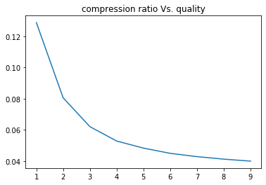

```python
N=10
quality=range(1,N)
img_ratio_vec=[]
for q in quality:
    jpeg_img=im2jpeg(img,quality=q)
    #res_img=jpeg2im(jpeg_img,quality=q)
    ratio=imratio(img,jpeg_img)
    img_ratio_vec.append(ratio)
plt.plot(quality,img_ratio_vec)
plt.title("compression ratio Vs. quality")
plt.show()
```

As we increase the quality the image compresses more, as expected!

1. The Root Mean Square (RMS) error of restoration is defined in the following way:  
   \begin{equation*} RMS = \left( \frac{1}{MN} \sum_{k=0}^{M-1} \sum_{k=0}^{N-1} (\hat{f}(i,j)-f(i,j))^2 \right)^{0.5} \end{equation*}

   where $f(i, j)$ is the original image, $\hat{f}(i,j)$ is the restored image and $M \times N$ is the size of both images.

   Plot the graph of Root Mean Square (RMS) Error of restoration (Y axis) versus compression ratio (X axis). This graph is called Rate-Distortion curve.

**Hint**: you can use the supplied functions *imratio*.

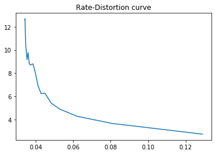

```python
N=20
quality=range(1,N)
img_ratio_vec=[]
rms_vec=[]
for q in quality:
    jpeg_img=im2jpeg(img,quality=q)
    res_img=jpeg2im(jpeg_img,quality=q)
    img_ratio_vec.append(imratio(img,jpeg_img))
    rms_vec.append(np.sqrt(np.average(np.power(res_img-img,2))))
plt.plot(img_ratio_vec,rms_vec)
plt.title("Rate-Distortion curve")
plt.show()
```

As expected, the RMS error increases when the image is more compressed. And decreases when the image is less compressed.

1. Repeat question 1 for block sizes **4X4** and **16X16**. Use the function *def zigzag(M, N)* that you wrote for the preliminary report.
   - Compare blocking effects for different block sizes.
   - Compare the performance of the algorithm for different block sizes.
   - What are the advantages and disadvantages of changing the block size?
   - Resize the quantization table array - use *tranform.resize* with the argument *preserve_range=True*

**Hint**: you also have to change the quantization table and the block size in the functions *im2jpeg* and *jpeg2im*.

```python
def zigzag(M, N):
    mat = np.arange(M*N).reshape(M,N)
    zig=np.concatenate([np.diagonal(mat[::-1,:],k)[::((-1)**(M-1))*(2*(k%2)-1)] for k in range(1-M,M+1)])
    return zig
zigzag_order_16x16=zigzag(16,16)
zigzag_order_4x4=zigzag(4,4)
```

[figure not shown]

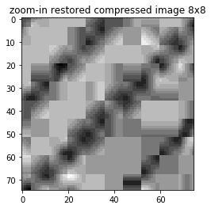

[figure not shown]

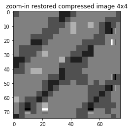

[figure not shown]

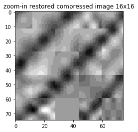

```python
jpeg_img=im2jpeg(img)
res_img=jpeg2im(jpeg_img)
plt.title("restored compressed image 8x8")
plt.imshow(res_img, cmap='gray')
plt.show()
res_img_zoom=res_img[100:175,100:175]
plt.title("zoom-in restored compressed image 8x8")
plt.imshow(res_img_zoom, cmap='gray')
plt.show()

jpeg4_img=im2jpeg(img,block_size=4)
res4_img=jpeg2im(jpeg4_img,block_size=4)
plt.title("restored compressed image 4x4")
plt.imshow(res4_img, cmap='gray')
plt.show()
res4_img_zoom=res4_img[100:175,100:175]
plt.title("zoom-in restored compressed image 4x4")
plt.imshow(res4_img_zoom, cmap='gray')
plt.show()

jpeg16_img=im2jpeg(img,block_size=16)
res16_img=jpeg2im(jpeg16_img,block_size=16)
plt.title("restored compressed image 16x16")
plt.imshow(res16_img, cmap='gray')
plt.show()
res16_img_zoom=res16_img[100:175,100:175]
plt.title("zoom-in restored compressed image 16x16")
plt.imshow(res16_img_zoom, cmap='gray')
plt.show()
```

block sizes/effects: we can see the blocking effects when zooming in (see above). Smaller block size: contains less edges (usually in normal images), and more low frequencies in the image, this is why the result of the DCT will have less coeffiecients, and the compression will be better. On the other hand, too small of a block_size emphasizes the boundaries between the blocks - more blocks, more boundaries.

1. Use the following python build in function for JPEG compression:

   ```
    result = Image.fromarray((img).astype(np.uint8))
    result.save(Compressed_File_Name,"JPEG",optimize=True,quality=Your_quality)
   ```

   - Compress your image by using this function.
   - Load and show the compressed image.
   - Pay attention to the compressed image size that you saved with respect to the original image size.
   - Plot the compressed image with quality of: 4, 10, 60.

**Note**: The 'quality' parameter is different here from the 'quality' parameter that we used in question 2.

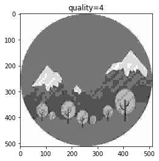

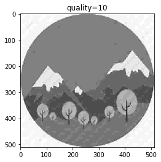

[figure not shown]

```python
result4 = Image.fromarray((img).astype(np.uint8))
result4.save("result4.jpg","JPEG",optimize=True,quality=4)
result4 = io.imread('result4.jpg')
plt.title("quality=4")
plt.imshow(result4, cmap='gray')
plt.show()

result10 = Image.fromarray((img).astype(np.uint8))
result10.save("result10.jpg","JPEG",optimize=True,quality=10)
result10 = io.imread('result10.jpg')
plt.title("quality=10")
plt.imshow(result10, cmap='gray')
plt.show()

result60 = Image.fromarray((img).astype(np.uint8))
result60.save("result60.jpg","JPEG",optimize=True,quality=60)
result60 = io.imread('result60.jpg')
plt.title("quality=60")
plt.imshow(result60, cmap='gray')
plt.show()
```

We note that the higher the quality the better the image is as opposed to question 2. Also we notice that for higher quality the image size is larger. so there is a tradeoff between the quality and the image size, as expected and as seen in previous sections.